# Angioplasty and stenting in the femoro-popliteal segment

Martin Hennessy, Keith Hussey

05/04/2020

# 1 Greater Glasgow & Clyde practice and outcomes since 2016

## 1.1 Basic details about project

### 1.1.1 Abbreviations

- IC = intermittent claudication
- RP = rest pain
- TL = tissue loss
- TASCII/TASC-II/TASC = Trans-Atlantic Inter-Society Consensus-II

### 1.1.2 Inclusion and exclusion criteria

- Indication criteria are:
  - Endovascular intervention to femoro-popliteal (fem-pop) segment
  - Intermittent claudication, rest pain and tissue loss
- Exclusion criteria are:
  - Femoro-popliteal bypass graft on ipsilateral leg
  - Acute limb ischaemia or other indication not listed above
  - Previous intervention to same limb is NOT an exclusion criterion

### 1.1.3 Period covered

- Procedures from 2016-01-11 to 2020-04-01 are included here

## 1.2 Patient information - number, year and age

### 1.2.1 Patients per year

- 505 are included
- They are spread across the years as demonstrated:

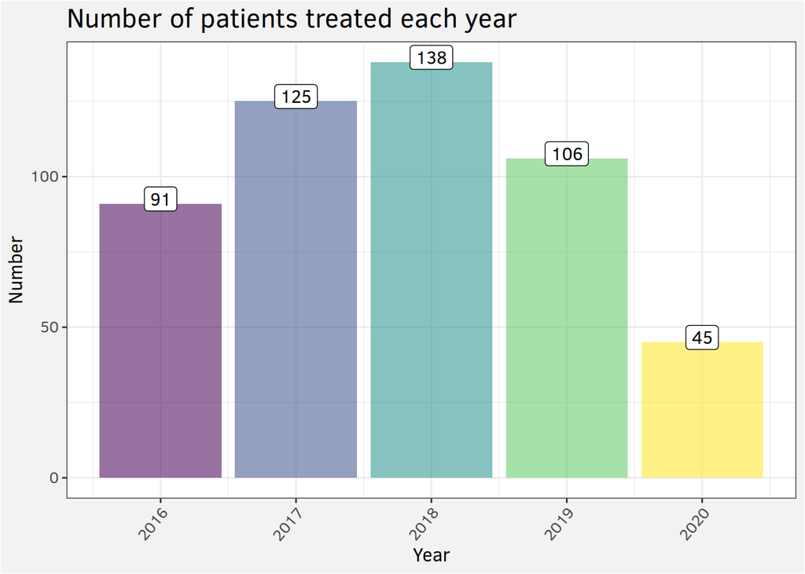

### 1.2.2 Age per year

- Mean age of patients is 70.3 years
- Median age of patients is 72 years
- Age is demonstrated in this boxplot:

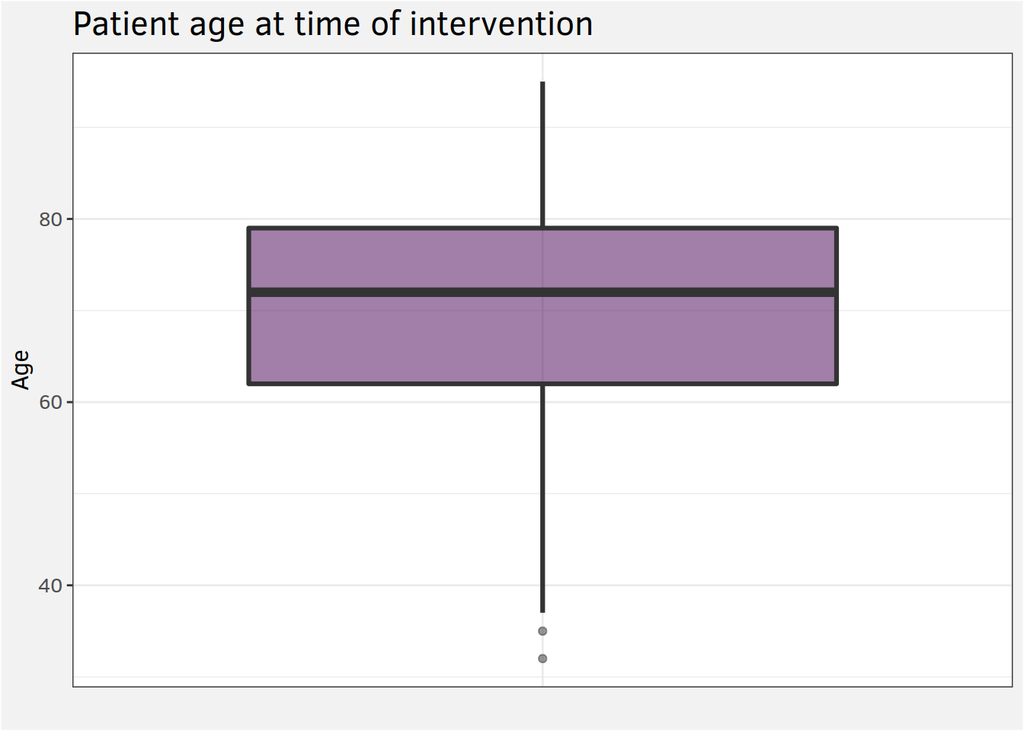

- Age variation by year is demonstrated in this boxplot:

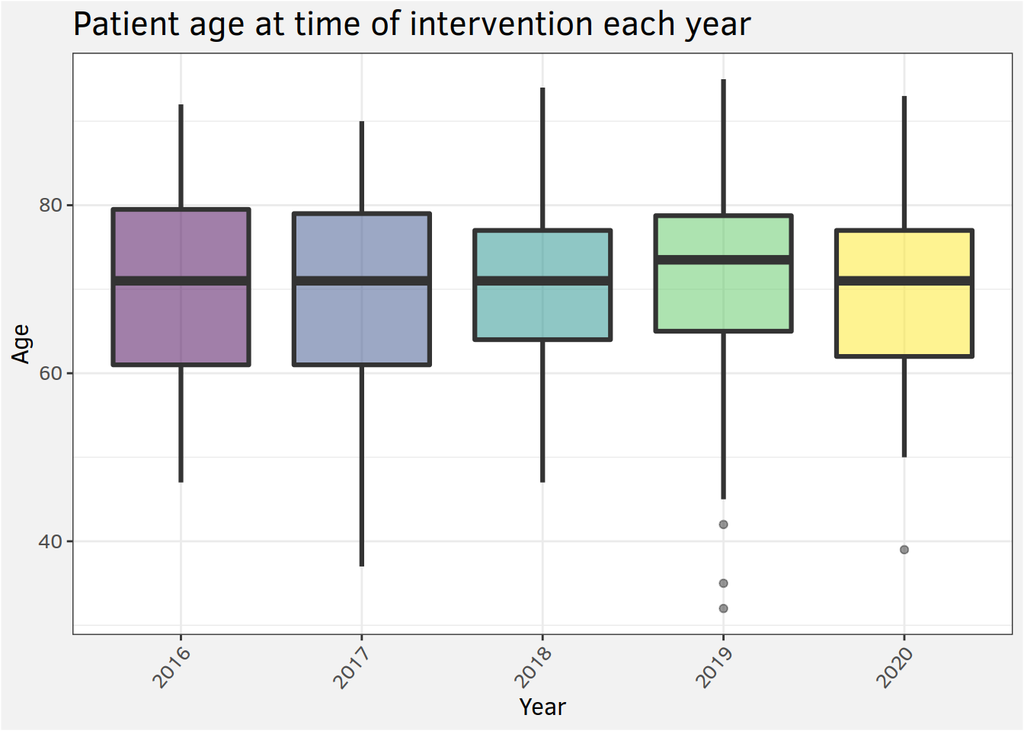

- Kruskal-Wallis test to look for differences between mean ages:

```
##
##  Kruskal-Wallis rank sum test
##
## data:  patients$Age by patients$Year
## Kruskal-Wallis chi-squared = 2.3866, df = 4, p-value = 0.6651
```

- Wilcoxon rank sum test to look for where differences in means are:
- (can be ignored if *p* >= 0.05 for Kruskal-Wallis test)

```
##
##  Pairwise comparisons using Wilcoxon rank sum test
##
## data:  patients$Age and patients$Year
##
##      2016 2017 2018 2019
## 2017 0.92 -    -    -
## 2018 0.92 0.92 -    -
## 2019 0.80 0.80 0.80 -
## 2020 0.92 0.96 0.92 0.80
##
## P value adjustment method: BH
```

### 1.2.3 Age per indication

- Average age by indication for intervention is as shown here:

| Indication | Mean age | Median age |
| --- | --- | --- |
| IC | 64.0 | 65.0 |
| RP | 70.2 | 71.5 |
| TL | 71.9 | 72.0 |

- These data are demonstrated in this boxplot:

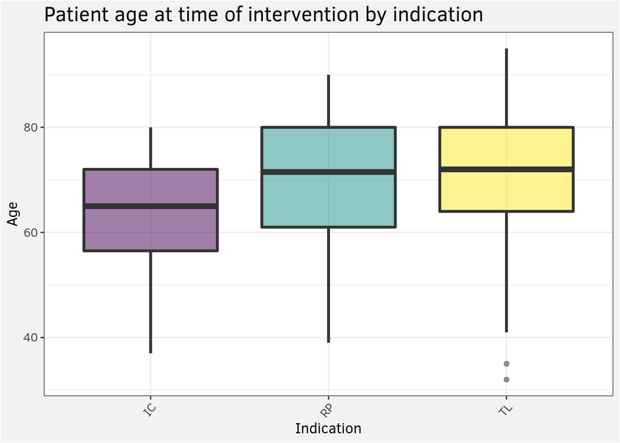

- Kruskal-Wallis test to look for differences between mean ages:

```
##
##  Kruskal-Wallis rank sum test
##
## data:  patients$Age by patients$Indication
## Kruskal-Wallis chi-squared = 36.29, df = 2, p-value = 1.318e-08
```

- Wilcoxon rank sum test to look for where differences in means are:
- (can be ignored if *p* >= 0.05 for Kruskal-Wallis test)

```
##
##  Pairwise comparisons using Wilcoxon rank sum test
##
## data:  patients$Age and patients$Indication
##
##    IC      RP
## RP 0.00099 -
## TL 2.8e-09 0.34004
##
## P value adjustment method: BH
```

### 1.2.4 Age per gender

- Average age by gender for intervention is as shown here:

| Gender | Mean age | Median age |
| --- | --- | --- |
| Man | 68.9 | 70 |
| Woman | 72.4 | 74 |

- These data are demonstrated in this boxplot:

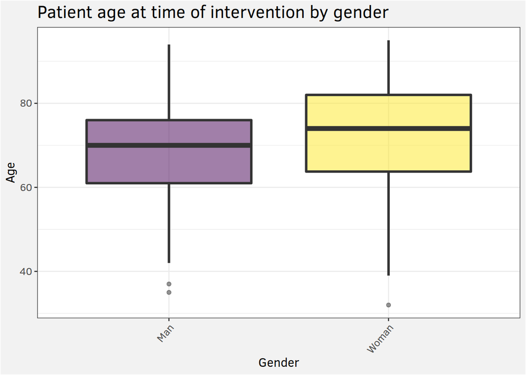

- Kruskal-Wallis test to look for differences between mean ages:

```
##
##  Kruskal-Wallis rank sum test
##
## data:  patients$Age by patients$Gender
## Kruskal-Wallis chi-squared = 13.952, df = 1, p-value = 0.0001875
```

## 1.3 Limb information - number and year

### 1.3.1 Limbs per year

- 551 are included
- They are spread across the years as demonstrated:

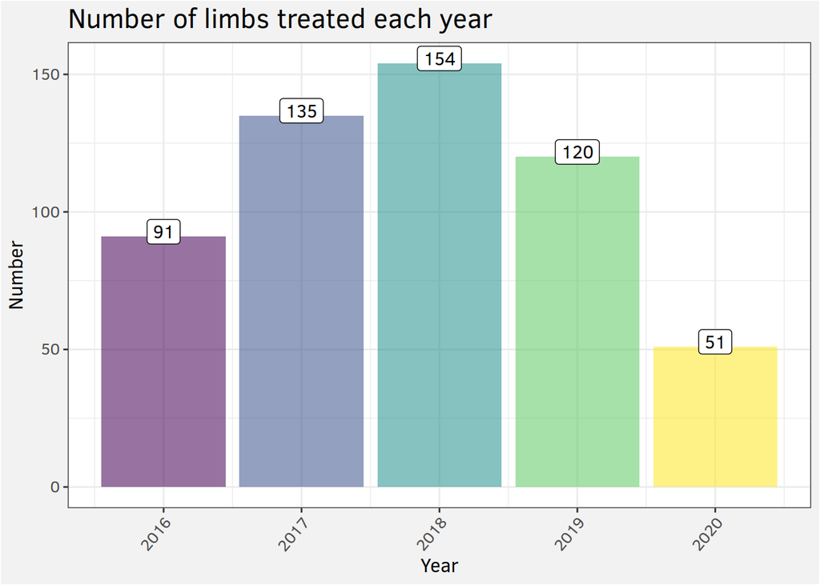

## 1.4 Procedure information - number, year and TASC classification

### 1.4.1 Procedures per year

- 622 are included
- They are spread across the years as demonstrated:

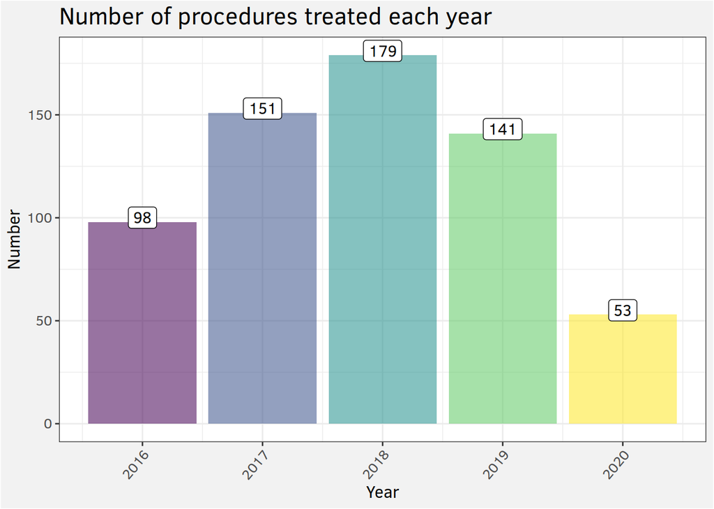

### 1.4.2 TASC classification of lesions

- These are from the 622 procedures

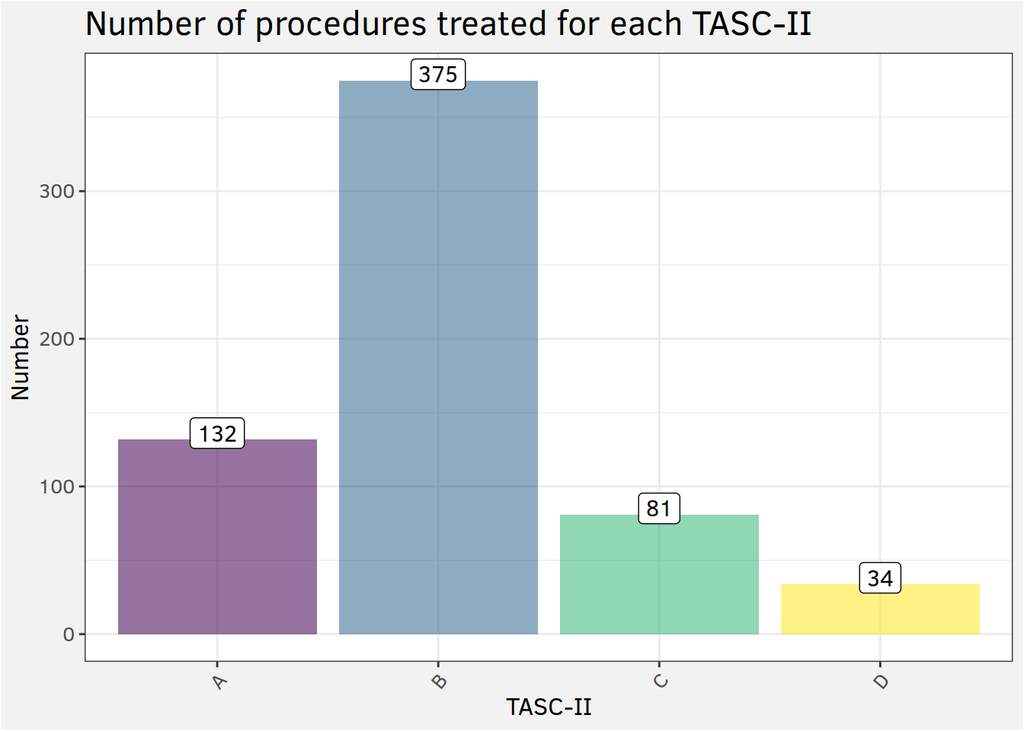

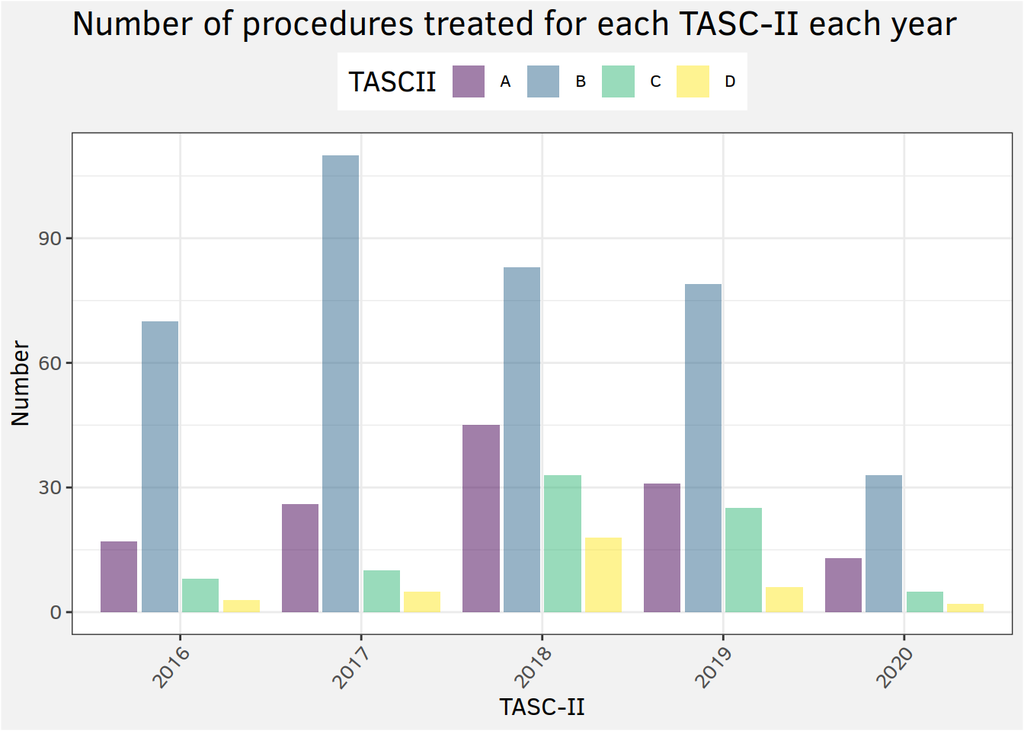

## 1.5 Symptom information - number, year and TASC

- Number of procedures performed for each indication are shown here:

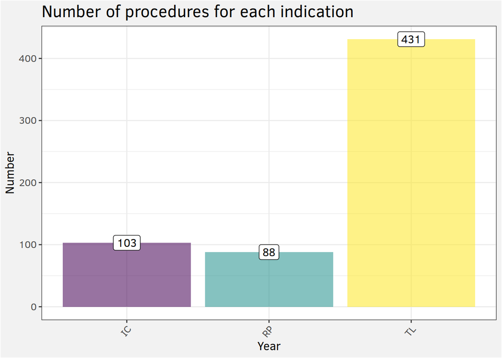

- Number of procedures each year for each indication are shown here:

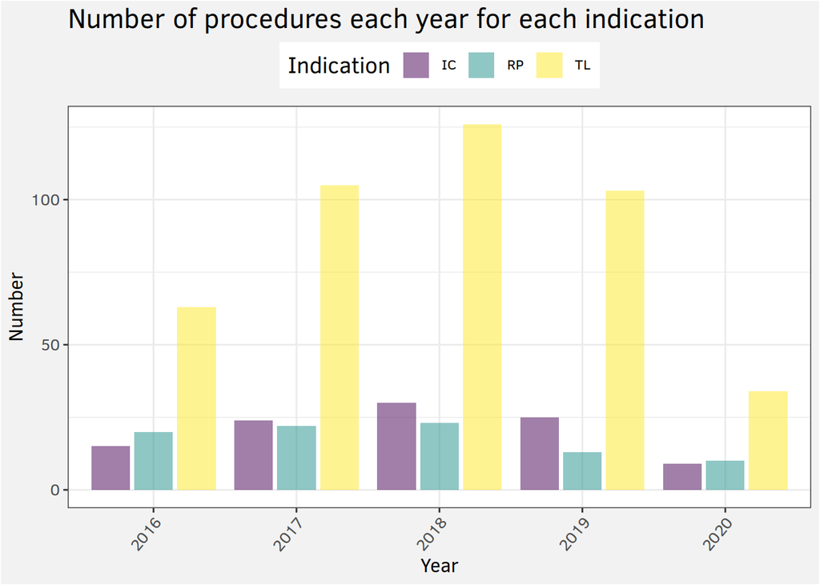

### 1.5.1 Intermittent claudication

#### 1.5.1.1 By year

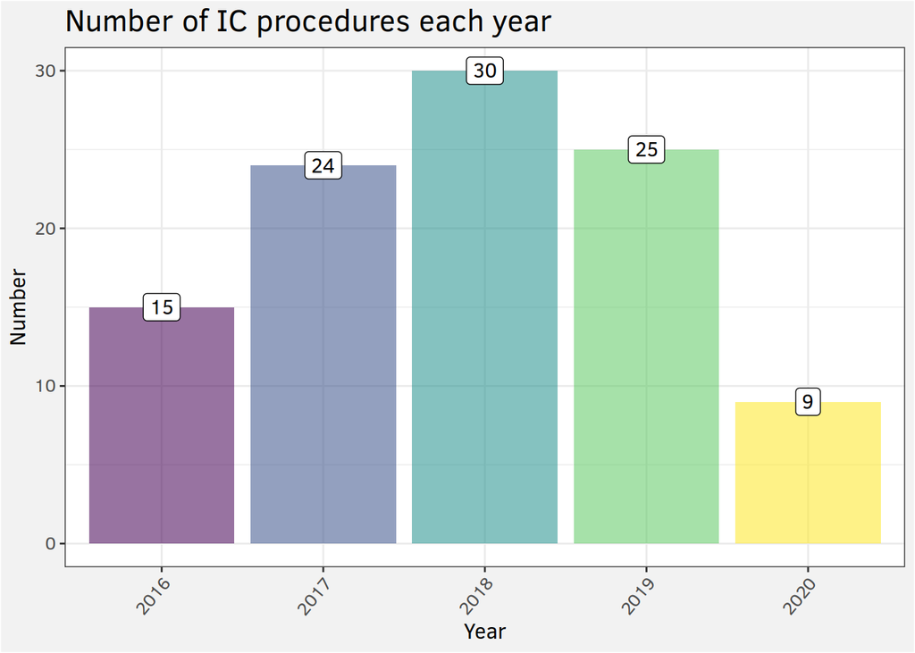

#### 1.5.1.2 By TASC

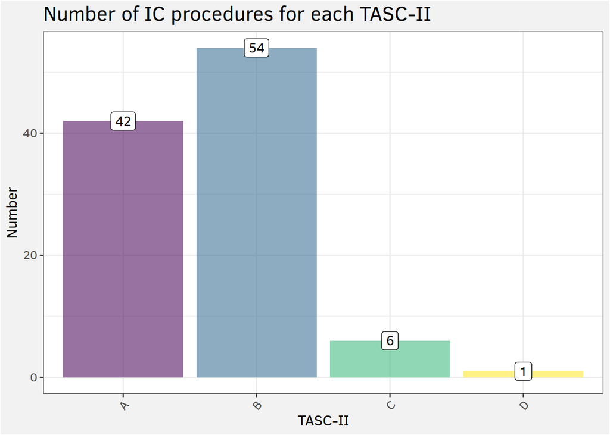

#### 1.5.1.3 By TASC each year

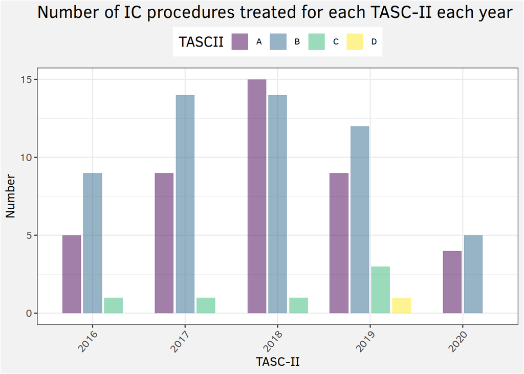

### 1.5.2 Rest pain

#### 1.5.2.1 By year

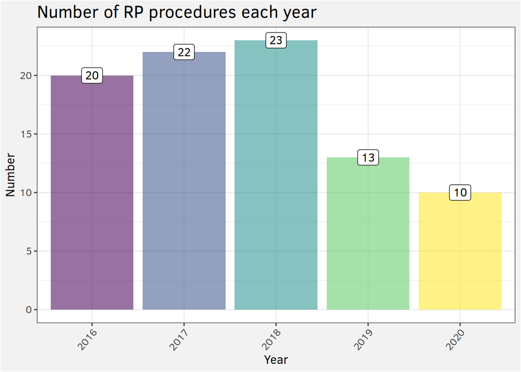

#### 1.5.2.2 By TASC

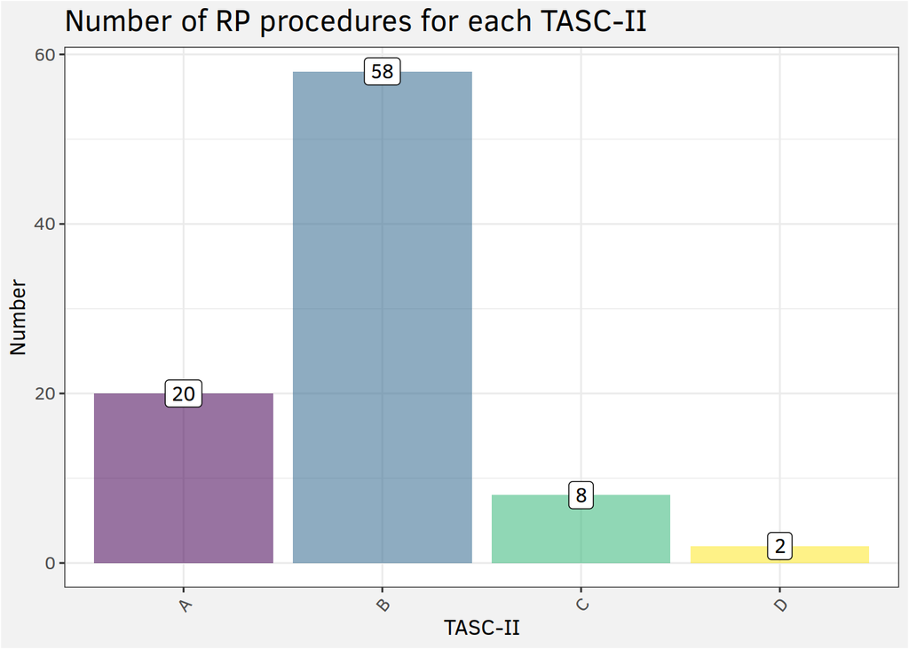

#### 1.5.2.3 By TASC each year

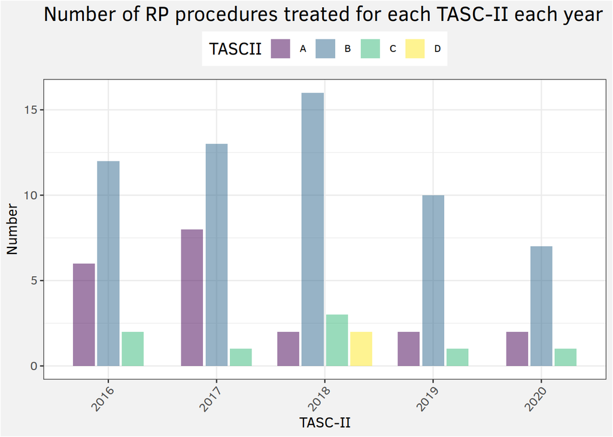

### 1.5.3 Tissue loss

#### 1.5.3.1 By year

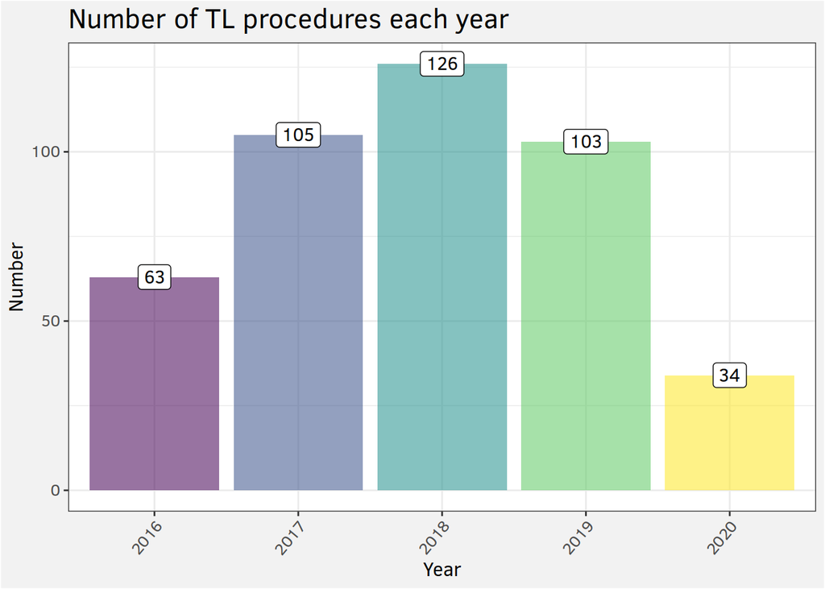

#### 1.5.3.2 By TASC

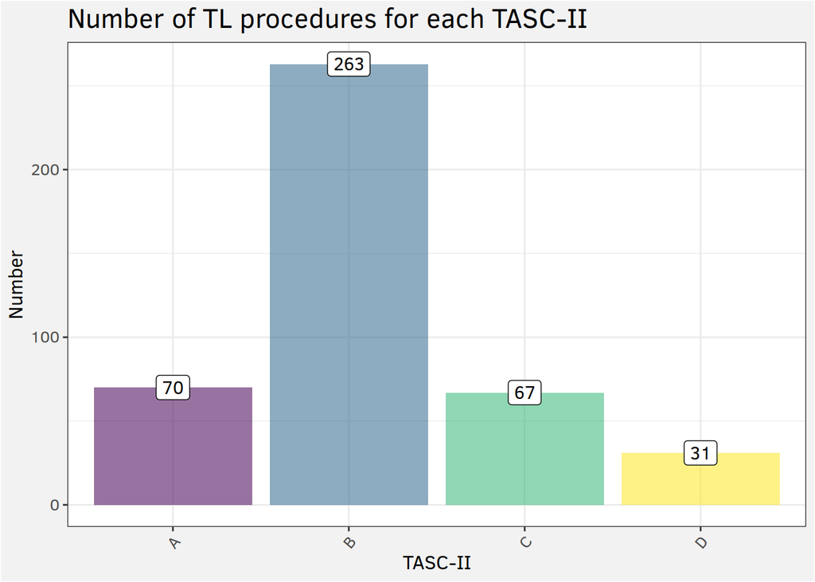

#### 1.5.3.3 By TASC each year

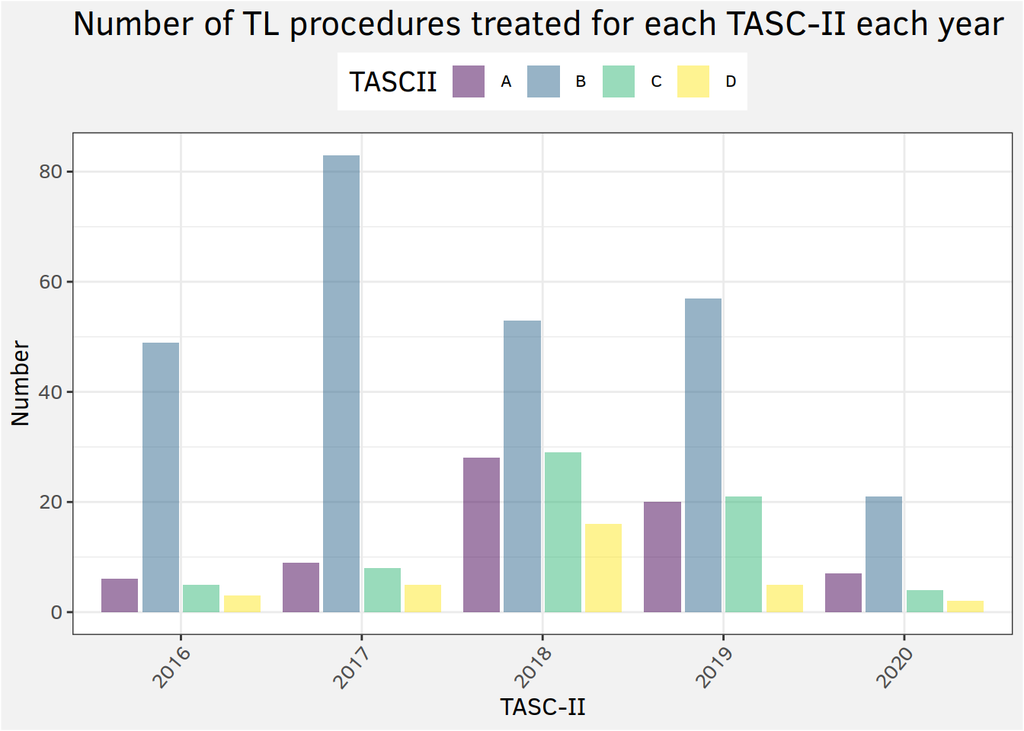

## 1.6 Technical success

### 1.6.1 Overall technical success

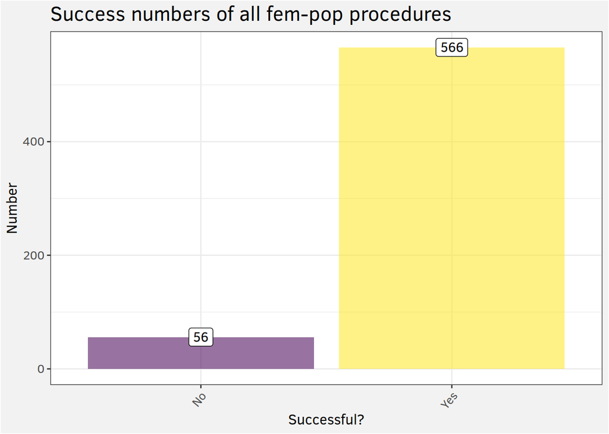

- 91% of all fem-pop procedures are technically successful

### 1.6.2 Technical success each year

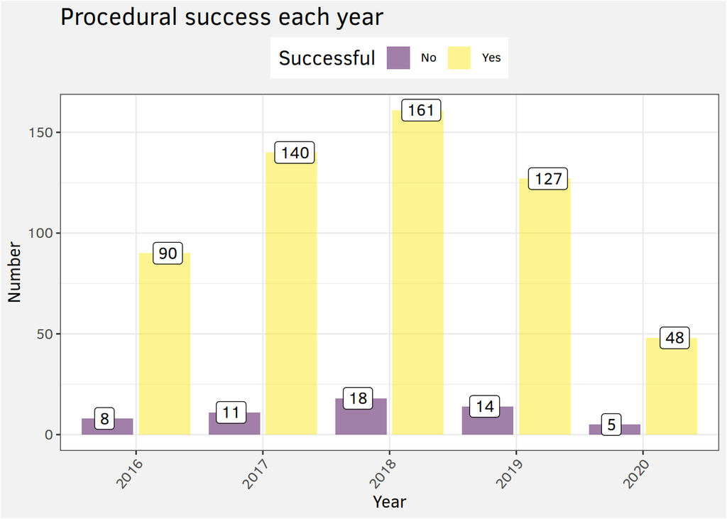

- Kruskal-Wallis test to look for difference in success between years:

```
##
##  Kruskal-Wallis rank sum test
##
## data:  procedures$Successful by procedures$Year
## Kruskal-Wallis chi-squared = 1.0287, df = 4, p-value = 0.9054
```

- Wilcoxon rank sum test to look for where differences in means are:
- (can be ignored if *p* >= 0.05 for Kruskal-Wallis test)

```
##
##  Pairwise comparisons using Wilcoxon rank sum test
##
## data:  procedures$Success and procedures$Year
##
##      2016 2017 2018 2019
## 2017 0.97 -    -    -
## 2018 0.97 0.97 -    -
## 2019 0.97 0.97 0.97 -
## 2020 0.97 0.97 0.97 0.97
##
## P value adjustment method: BH
```

### 1.6.3 Technical success by symptom

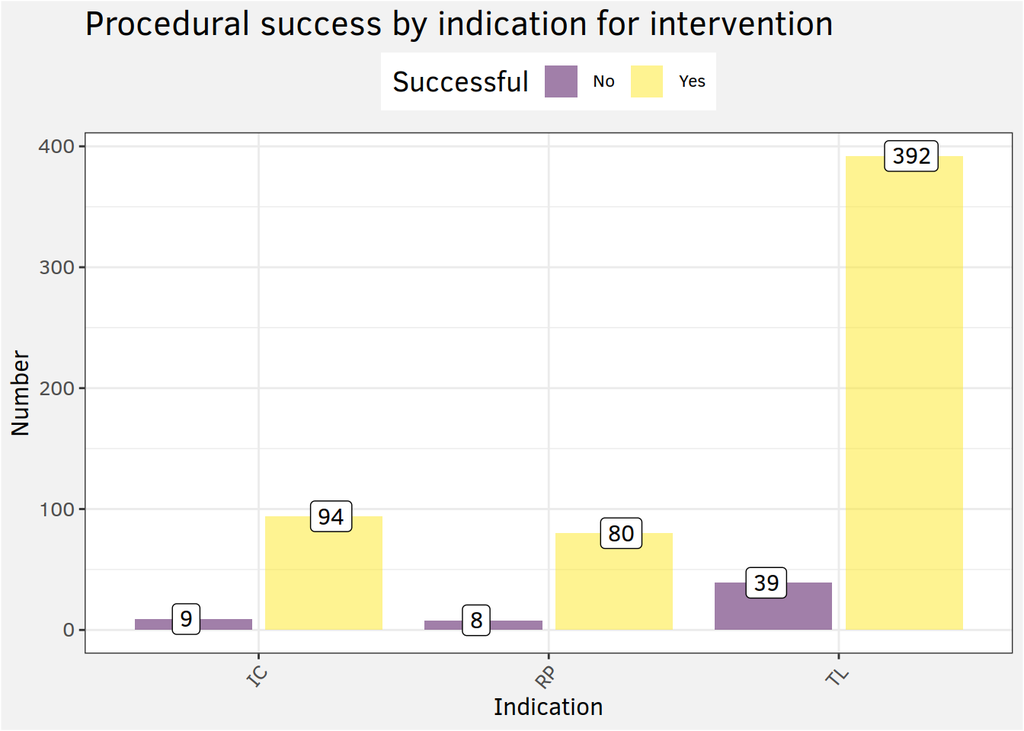

- Kruskal-Wallis test to look for difference in success between indications:

```
##
##  Kruskal-Wallis rank sum test
##
## data:  procedures$Successful by procedures$Indication
## Kruskal-Wallis chi-squared = 0.010751, df = 2, p-value = 0.9946
```

- Wilcoxon rank sum test to look for where differences in means are:
- (can be ignored if *p* >= 0.05 for Kruskal-Wallis test)

```
##
##  Pairwise comparisons using Wilcoxon rank sum test
##
## data:  procedures$Success and procedures$Indication
##
##    IC   RP
## RP 0.99 -
## TL 0.99 0.99
##
## P value adjustment method: BH
```

### 1.6.4 Technical success by TASC-II

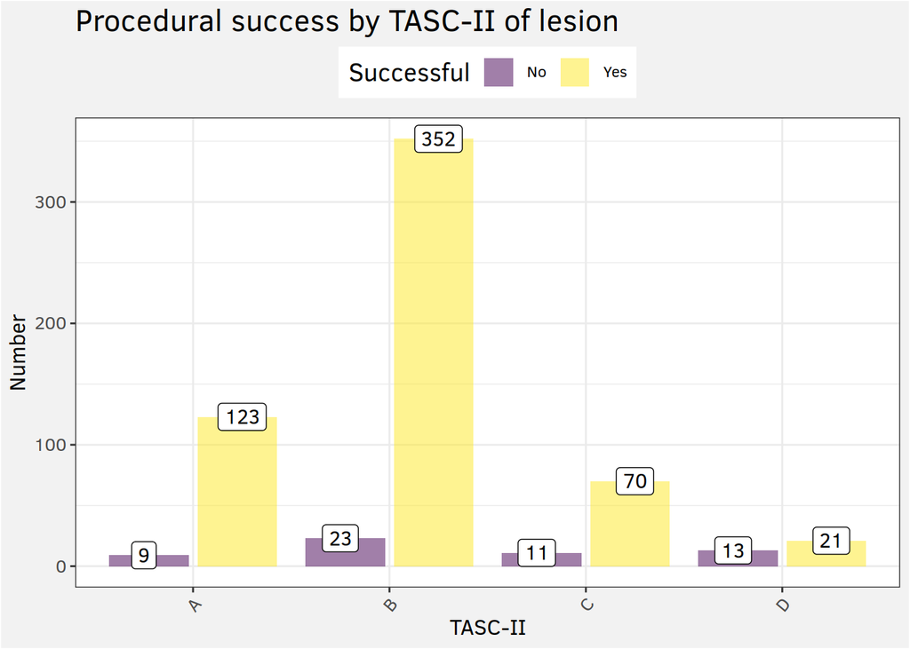

```
##
##  Kruskal-Wallis rank sum test
##
## data:  procedures$Successful by procedures$TASCII
## Kruskal-Wallis chi-squared = 42.006, df = 3, p-value = 4.001e-09
```

- Wilcoxon rank sum test to look for where differences in means are:
- (can be ignored if *p* >= 0.05 for Kruskal-Wallis test)

```
##
##  Pairwise comparisons using Wilcoxon rank sum test
##
## data:  procedures$Success and procedures$TASCII
##
##   A       B       C
## B 0.7816  -       -
## C 0.1221  0.0313  -
## D 4.8e-06 1.6e-09 0.0063
##
## P value adjustment method: BH
```

Home